## Curso de R no IPÊ

### Script do dia 4.3: Mantel

*Marcos V. C. Vital e participantes da turma de 2014*

Para mais material, acesse http://marcosvital.wordpress.com/

Este documento é a 3a e última parte do quarto de uma série que nasceu durante as atividades do “Curso de introdução ao uso do software R e suas aplicações estatísticas nas ciências biológicas”, realizado no IPÊ em dezembro de 2014.

Nesta parte do guia nós vamos realizar um teste de Mantel, um teste de Mantel parcial e calcular um correlograma.

Como sempre, todo o documento foi criado utilizando o software R, o programa RStudio e a linguagem Markdown. Para saber mais, acesse:

http://www.r-project.org/

http://www.rstudio.com

http://rmarkdown.rstudio.com/

**Antes de começar, carregue os dados necessários:**

Mentira, desta vez vamos usar dados que já estão disponíveis no R, que tal?

```r
library(vegan)
data(mite)
data(mite.env)
data(mite.xy)
```

A função `data` carrega pacotes que fazem parte dos exemplos do R.

#### O teste de Mantel

Sua execução é bem simples no R, basta usar a função `mantel`, então vejamos um exemplo:

```r
dist.amb<-dist(scale(mite.env[,1:2]), method="euclid")
dist.jac<-vegdist(mite, method="jac", binary=T)

mantel(dist.amb, dist.jac)
```

```
##
## Mantel statistic based on Pearson's product-moment correlation
##
## Call:
## mantel(xdis = dist.amb, ydis = dist.jac)
##
## Mantel statistic r: 0.4263
##       Significance: 0.001
##
## Upper quantiles of permutations (null model):
##    90%    95%  97.5%    99%
## 0.0611 0.0801 0.0971 0.1128
##
## Based on 999 permutations
```

O gráfico a seguir pode ser útil para se pensar no resultado:

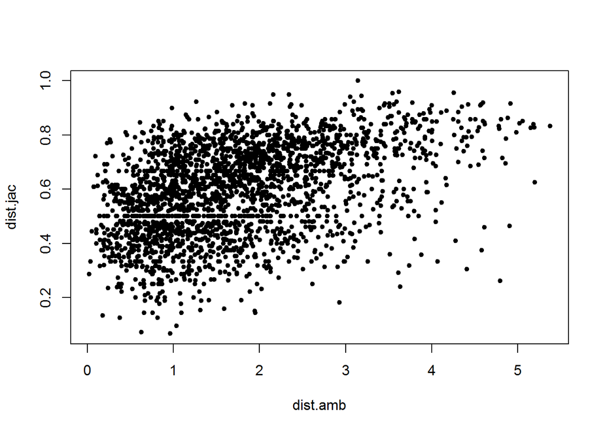

```r
plot(dist.amb, dist.jac, pch=20)
```

#### O teste de Mantel Parcial

Também não há complicações aqui, basta usar a função `mantel.partial`:

```r
dist.geo<-dist(mite.xy, method="euclid")

mantel.partial(dist.amb, dist.jac, dist.geo)
```

```
##
## Partial Mantel statistic based on Pearson's product-moment correlation
##
## Call:
## mantel.partial(xdis = dist.amb, ydis = dist.jac, zdis = dist.geo)
##
## Mantel statistic r: 0.3323
##       Significance: 0.001
##
## Upper quantiles of permutations (null model):
##    90%    95%  97.5%    99%
## 0.0863 0.1113 0.1344 0.1589
##
## Based on 999 permutations
```

#### E o correlograma de mantel

De novo, nada de complicado, basta usar a função `mantel.correlog` (mas você pode querer explorar mais a função para determinar as classes de distância manualmente, por exemplo).

Segue um exemplo rápido de execução:

```r
correlograma<-mantel.correlog(dist.amb, dist.geo)

correlograma
```

```
##
## Mantel Correlogram Analysis
##
## Call:
##
## mantel.correlog(D.eco = dist.amb, D.geo = dist.geo)
##
##         class.index      n.dist  Mantel.cor Pr(Mantel) Pr(corrected)
## D.cl.1    0.5141820 358.0000000   0.0994010      0.001         0.001 ***
## D.cl.2    1.2425460 650.0000000   0.1152941      0.001         0.002 **
## D.cl.3    1.9709099 796.0000000   0.1050915      0.001         0.003 **
## D.cl.4    2.6992739 696.0000000   0.0419353      0.026         0.026 *
## D.cl.5    3.4276379 500.0000000   0.0053958      0.422         0.422
## D.cl.6    4.1560019 468.0000000  -0.0338560      0.054         0.108
## D.cl.7    4.8843659 364.0000000  -0.0538239      0.005         0.020 *
## D.cl.8    5.6127298 326.0000000          NA         NA            NA
## D.cl.9    6.3410938 260.0000000          NA         NA            NA
## D.cl.10   7.0694578 184.0000000          NA         NA            NA
## D.cl.11   7.7978218 130.0000000          NA         NA            NA
## D.cl.12   8.5261858  66.0000000          NA         NA            NA
## D.cl.13   9.2545497  32.0000000          NA         NA            NA
## ---
## Signif. codes:  0 '***' 0.001 '**' 0.01 '*' 0.05 '.' 0.1 ' ' 1
```

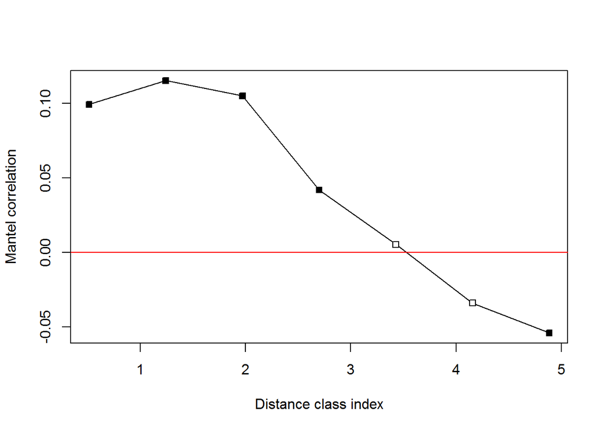

```r
plot(correlograma)
```

#### Extra! Índices de diversidade de brinde!

Como em sala acabamos falando um pouco sobre os índices e os perfis de diversidade, seguem aqui os procedimentos que realizamos.

**Calculando o índice de Shannon:**

```r
diversity(colSums(mite), index="shannon")
```

```
## [1] 2.65044
```

**Calculando o índice de Simpson:**

```r
diversity(colSums(mite), index="simpson")
```

```
## [1] 0.885881
```

**Deixando os índices pra la, e calculando um perfil de diversidade:**

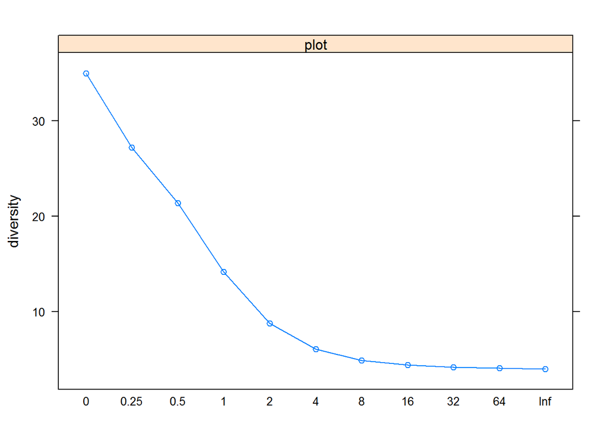

```r
plot(renyi(colSums(mite), hill=T), type="b")
```

**E é isso aí! Conseguimos avançar quatro dias.**

**Agora nos vemos nos documentos do último dia!**